# Day 2 & 3 & 4 - Data structures

Rajeev

Today we look at some of the ways that R can store and organize data. R provides a number of data structures we can use to store and organize data to make data analysis easy. We will discuss the most important data structures in base R.

But before getting started with Data Structures we will start with a basic concept in programming languages called variable. We discussed in Day 1 that R generally works in terms of variables and functions. We saw what functions and variables are, but let’s dig a little deeper into the meaning of a variable.

## Variables

While doing programming in any programming language, you need to use various variables to store information. Variables provide a means of accessing the data stored in memory. This means that, when you create a variable you reserve some space in memory which can be used to store values. You can use the variable’s name to easily access the value that is stored within the memory location.

You can assign value 3 to a variable x with the either of the following commands `->` or `=`as discussed in Day 1. When you type x on console and press enter, you get the value of x.

```r
> x <- 3
> y = 3
> x
```

```
## [1] 3
```

There are some restrictions in naming variables. A valid variable name consists of letters, numbers and the dot (.) or underline (_) characters. The variable name starts with a letter or the dot not followed by a number.

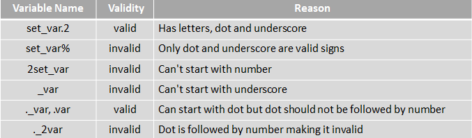

The variables starting with dot are hidden variables. When you use the `ls()` command to list all the variables in current R session you will not be able to see these variables by default. To see the hidden variables use the `ls` function like this `ls(all.name = TRUE)`. `all.names` is a function parameter. In a later session on functions you will get to know what `all.name = TRUE` inside of `ls` function means.

### Reserved Words

Finally, in R there are a set of words that have special meaning called Reserved words. They cannot be used as an variable names. Here is a list of reserved words in the R’s parser. You can also check list of all the reserved words in R by the help feature `?reserved`.

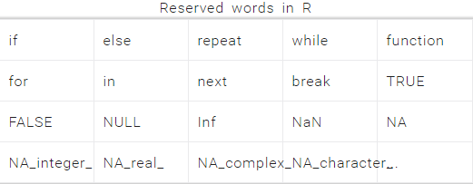

Among these words, `if, else, repeat, while, function, for, in, next and break` are used for conditions, loops and user defined functions. They form the basic building blocks of programming in R which you will be learning a bit later. `TRUE` and `FALSE` are the logical constants in R. `NULL` represents the absence of a value or an undefined value. `Inf` is for “Infinity”, for example when 1 is divided by 0 whereas `NaN` is for “Not a Number”, for example when 0 is divided by 0. `NA` stands for “Not Available” and is used to represent missing values in data. You can try looking for more details about these using the `help` function.

## Basic Data Structures in R

R provides a number of specialized data structures we will refer to as objects. All the things we encounter and manipulate in R are R-Objects, or simply objects.

The most commonly used R-Objects are

- Vectors (Atomic Vectors)
- Lists (Generic Vectors)
- Matrices
- Arrays
- Factors
- Data Frames

**NOTE:** Atomic vectors are usually refered as vectors. We will see another kind of vectors called Generic Vectors, which are usually refered as Lists.

There are the basic data structures in R. Several other complex objects are built upon these basic objects. We will look into these data structures in detail today.

## Basic Types of Data in R

Objects can contain different types of data. There are six basic data types of objects.

- Logical
- Numeric
- Integer
- Character
- Complex
- Raw

Out of these first four are most commonly used and the last two are almost never used so you can ignore them if you dont understand how they work.

Instead of chewing through the language specification, we will try to understand them better by direct experimentation with the R code. We define variables using either `=` or `->` as discussed earlier. The `typeof` function will tell you which data type the variable is.

Try these examples on your console and what they print.

```r
> # Logical, used to store TRUE or FALSE
> # Examples: TRUE, FALSE. You can even use T or F.
> v = TRUE
> print(v)
```

```
## [1] TRUE
```

```r
> typeof(v)
```

```
## [1] "logical"
```

```r
>
> # Remember R is case sensitive, so TRUE and True is not the same. Try giving v = True, it will give an error.
>
> # Numeric, used to store real values
> # Examples: 2.3, 4.5, 5
> v <- 23.5
> print(v)
```

```
## [1] 23.5
```

```r
> typeof(v)
```

```
## [1] "double"
```

```r
>
> # Note that you will get double as output when you use typeof on numeric variables. numeric and double are basically the same thing.
>
> # Integer, used to store integer values
> # Examples: 5L, 10L
> v <- 5L
> print(v)
```

```
## [1] 5
```

```r
> typeof(v)
```

```
## [1] "integer"
```

```r
>
> #Note that whenever you create an integer without L suffix it will be created as a numeric. For example try the following example and check the typeof of v.
>
> v = 5
> typeof(v)
```

```
## [1] "double"
```

```r
>
> # Character, used to store characters or strings
> # Examples: 'a', "krsna", 'hello'. You can use single quotes '' or doble quotes ""
> v <- "data"
> print(v)
```

```
## [1] "data"
```

```r
> typeof(v)
```

```
## [1] "character"
```

```r
>
> # Complex, used to store complex values. Not so important
> # Examples: 2+4i
> v <- 2 + 3i
> print(v)
```

```
## [1] 2+3i
```

```r
> typeof(v)
```

```
## [1] "complex"
```

```r
>
> # Raw, used to store raw values. Not so important
> # Examples: "Hello" will be stored as 48 65 6c 6c 6f
> v <- charToRaw("Hello")
> print(v)
```

```
## [1] 48 65 6c 6c 6f
```

```r
> typeof(v)
```

```
## [1] "raw"
```

Before ending this section I want to explain one important thing abiut R. As we discussed earlier, everything in R is an object. When you create a variable in R, it will be created as an R-Object. In the examples you tried earlier, when you define variable `v`, what actually happens is, a vector object `v` of length one is created and this vector object will hold the values of different data types. In the next section on vectors I will explain it in more detail.

## Atomic Vectors

Atomic Vector is the simplest data structure in R. A vector is a sequence of data elements of the same data type.

### Creating Vectors

Vectors are created using `c()` function.

```r
> v = c(1,2,3,4)
> v
```

```
## [1] 1 2 3 4
```

Suppose you want to create a vector containing integers from 1 to 100. You can create it y using `:` operator.

```r
> v = c(1:100) # creates vector containing 1 to 100
> v = 1:100 # you dont need to use c() here. this will also work
```

**Quick Questions**

1. What will happen if you create vector using `v = 4.5:10.5` and `v = 4.5:11.3`?  
   Ans: Both will give a sequence of 4.5 to 10.5 incrementing by 1, i.e, `4.5 5.5 6.5 7.5 8.5 9.5 10.5`. If the final element specified does not belong to the sequence then it is discarded.
2. What does the function `seq()` does? (HINT: Read documentation using ?seq)
3. What does this do? `v = c()`. What is `NULL`? (Read Documentation using ?NULL)

### Properties of Vectors

The vector have 3 common properties.

- Type, `typeof()`, What type of data it’s holding
- Length, `length()`, how many elements it contains
- Attributes, `attributes()`, additional metadata (metadata means data that describes and gives information about other data, here metadata gives additional information about vector)

To check what type of data vector holdes use `typeof()` function. Vector can contain any of the 6 basic types logical, integer, numeric or double, complex, string (or character). Using `length()` function you can determine the length property of the vector. We will discuss more about attributes in a bit. But for now if you check for attributes of vectors created by `c()` function you will get `NULL`.

The following code demonstrates creating a vector of numeric, character & logical type.

```r
> # Numeric vector
> num_vec = c(1,2,3,4)
> num_vec
```

```
## [1] 1 2 3 4
```

```r
> typeof(num_vec)
```

```
## [1] "double"
```

```r
> length(num_vec)
```

```
## [1] 4
```

```r
> attributes(num_vec)
## NULL
> # character vector
> char_vec = c("aa", "bb", "cc", "dd", "ee")
> char_vec
```

```
## [1] "aa" "bb" "cc" "dd" "ee"
```

```r
> typeof(char_vec)
```

```
## [1] "character"
```

```r
> length(char_vec)
```

```
## [1] 5
```

```r
> attributes(char_vec)
## NULL
> # Logical vector
> log_vec = c(T,F,F,T)
> log_vec
```

```
## [1]  TRUE FALSE FALSE  TRUE
```

```r
> typeof(log_vec)
```

```
## [1] "logical"
```

```r
> length(log_vec)
```

```
## [1] 4
```

```r
> attributes(log_vec)
## NULL
```

We can check if the given variable is a atomic vector using `is.atomic()` function. It returns `TRUE` is the variable is an atomic vector. Similarly we can check the type of vector using the functions `is.numeric()`, `is.double`, `is.logical()`, `is.integer()`, `is.character`. Note that `is.numeric()`returns `TRUE` for both integer and double vectors, however `is.double` won’t return `TRUE` for integers.

```r
> a = c(T,F,F,T)
> length(a)
```

```
## [1] 4
```

```r
> is.atomic(a)
```

```
## [1] TRUE
```

```r
> is.integer(a)
```

```
## [1] FALSE
```

```r
> is.character(a)
```

```
## [1] FALSE
```

```r
> is.numeric(a)
```

```
## [1] FALSE
```

```r
> is.double(a)    # is.numeric() and is.double() are esentially same
```

```
## [1] FALSE
```

```r
> is.character(a)
```

```
## [1] FALSE
```

### Accessing Elements in Vector

Elements of a vector can be accessed using indexing operation `[]`. Inside the operation `[]` we can use either integers, logical or character for indexing.

Vector index in R starts from 1 unlike many other programming languages. This code illustrates using integers for indexing.

```r
> # Using integers for indexing
> v = c(1,2,3,4,5,6,7,8)
> v[1]  # prints 1st element
```

```
## [1] 1
```

```r
> v[c(1,2)] # prints 1st and 2nd element
```

```
## [1] 1 2
```

```r
> v[2:5] # prints 2nd to 5th element
```

```
## [1] 2 3 4 5
```

```r
> v[-1] # prints all element sexcept 1st one
```

```
## [1] 2 3 4 5 6 7 8
```

```r
> v[-1:-3] # prints all elements except 1:3, i.e 1,2,3
```

```
## [1] 4 5 6 7 8
```

```r
> v[-c(3, 1)] # prints all elements except 1st and 3rd
```

```
## [1] 2 4 5 6 7 8
```

```r
> v[c(2.5, 4.6)] # real numbers are truncated to integes, so this will give 2nd and 4th element
```

```
## [1] 2 4
```

```r
> v[c(2, -4)] # cant use both negetive and positive indexes. this gives error
```

```
## Error in v[c(2, -4)]: only 0's may be mixed with negative subscripts
```

You can also use logicals inside `[]`. When we use a logical vector for indexing, the position where the logical vector is TRUE is returned.

```r
> v = c(1,2,3,4,5,6,7,8)
> v[c(TRUE, TRUE, FALSE, FALSE, T, T, F, F)] # prints all elements in positions where TRUE or T is present
```

```
## [1] 1 2 5 6
```

```r
> v[c(T,F)] # if the logical vector given inside [] is shorter than the vector, it will be recycled to be the same length. so this operation is equivalant to v[c(T,F,T,F,T,F,T,F)]
```

```
## [1] 1 3 5 7
```

From the indexing operations seen above you can see how easily we can access elements of vector. There is one other way to access elements of vector, that is using `names`. As we have discussed earlier, vectors have three common properties type, length and attributes. Attributes are the metadata which describes the data present inside the boject. `names` is a kind of attribute which allows us to name the elements of the vector. I will discuss about other attributes later, but for now let’s name vector elements.

We can name each elements of a vector like this.

```r
> v = c("first"=1, "second"=2, "third"=3)
> v # see the differnce when printing vector with names
```

```
##  first second  third
##      1      2      3
```

By using `names()` function we can view the names of vector. If we don’t have any names we get `NULL` using `names()`. Using `attributes()` function we can see all the attributes present. Try the following functions out.

```r
> names(v)
```

```
## [1] "first"  "second" "third"
```

```r
> attributes(v)
```

```
## $names
## [1] "first"  "second" "third"
```

We can index using names as follows.

```r
> v["first"] # prints the element with "first" name
## first
##     1
> v[c("first", "second")] # prints elements with names, "first" and "second"
```

```
##  first second
##      1      2
```

### Modifying a Vector

Whenever we want to modify something in R we use assignment operator, `->` or `=`.

We can modify a vector using the assignment operator. We can use the techniques discussed above to access specific elements and modify them. If we want to truncate the elements, we can use reassignments.

```r
> v = c(1,2,3,4,5,6)
> v[2] = 12 # modify second element
> v[1:3] = 5 # modify elements from 1 to 3
> v = v[1:4] # truncate vector to first 4 elements
> v = c(v, 5, 6, 7) # can also modify vector like this
```

Suppose we have a vector `v = c(1,2,3)`. the length of vector is `3`. To increase the length of the vector, we can just assign 4th element such as `v[4] = 4`.

```r
> v = 1:3
> v[4] = 4
> v
```

```
## [1] 1 2 3 4
```

**Quick Questions**

1. Suppose there is vector `v = 1:3`. Now you assign 5th element `v[5] = 5`. What will be the output if you run `v[4]`?
2. Suppose there is a vector `v = 1:5`. `length(v)` will give `5`. What will happen if you change length using `length(v) = 7`?

### Deleting a Vector

We can delete a vector by just assigning a `NULL` to it. Or we can simply delete the vector using `rm()` function, which completly removes the object from workspace.

```r
> x = c(1,2,3,4)
> x = NULL # assigns vector v to NULL
> x # returns null
## NULL
> rm(x) # completly removes the vector v. Y
> x #if you try to print vector after returning you will get an error
```

```
## Error in eval(expr, envir, enclos): object 'x' not found
```

### `str()` function

`str()` is a very handy function and used very often. `str` means structure. This function answers the question “What’s in this object?”. It compactly display the internal structure of an R object. If you want to know what a R-object contains this function can be used.

For example if we use this function on a vector `v` as created below, we get the output `num [1:5] 1 2 3 4 5`. num means numeric type vector, and [1:5] describes there are 5 elements in vector and then it prints some elements of the vector.

```r
> v = c(1,2,3,4,5)
> str(v)
```

```
##  num [1:5] 1 2 3 4 5
```

### Vector Manipulation

Two vectors of same length can be added, subtracted, multiplied or divided giving the result as a vector output.

```r
> v = c(3,4,6,7,8)
> x = 1:5
> v+x
```

```
## [1]  4  6  9 11 13
```

```r
> v-x
```

```
## [1] 2 2 3 3 3
```

```r
> v/x
```

```
## [1] 3.00 2.00 2.00 1.75 1.60
```

```r
> v*x
```

```
## [1]  3  8 18 28 40
```

If we apply arithmetic operations to two vectors of unequal length, then the elements of the shorter vector are recycled to complete the operations.

```r
> v = c(2,3,5,6,7,9)
> x = 1:2
> v+x
```

```
## [1]  3  5  6  8  8 11
```

```r
> v-x
```

```
## [1] 1 1 4 4 6 7
```

```r
> v/x
```

```
## [1] 2.0 1.5 5.0 3.0 7.0 4.5
```

```r
> v*x
```

```
## [1]  2  6  5 12  7 18
```

### Coercion

All elements of an atomic vector must be the same type, so when you attempt to combine different types they will be coerced to the most flexible type. Types from least to most flexible are: logical, integer, double, and character.

For example, combining a character and an integer yields a character:

```r
> v = c('a', 1, 3)
> v
```

```
## [1] "a" "1" "3"
```

```r
> typeof(v)
```

```
## [1] "character"
```

When a logical vector is coerced to an integer or double, TRUE becomes 1 and FALSE becomes 0. You can explisitly convert a logical vector to numeric using `as.numeric()` function. This is sometimes very useful in data analysis.

```r
> v = c(5, T, F)  # T, F automatically coerced to 1 and 0 due to having 5
> v
```

```
## [1] 5 1 0
```

```r
> x = c(T,F,F,T,F)
> as.numeric(x)  # using as.numeric will convert logical into numeric vector.
```

```
## [1] 1 0 0 1 0
```

### Vectors of length one

So, what happens if we declare a variable like `v = 3` or `v = "hello"` like we did in last section. When you create a variable such as `v = 3`, you might expect that a numeric variable of value 3 is created like in other programming languages. But a vector object of length 1 is created and the type of that vector becomes numeric. As we have discussed at the end of *Basic Types of Data in R* section, everything in R is an object. You can not create a variable of individual data types.

You can try the following lines of code and see that we get both `as.atomic` and `as.numeric` as `TRUE` and length 1.

```r
> v = 3
> is.atomic(v)
```

```
## [1] TRUE
```

```r
> is.numeric(v)
```

```
## [1] TRUE
```

```r
> length(v)
```

```
## [1] 1
```

**Quick Questions**

1. Create a vector v containing integers from 1 to 10. What will the following opetations give `v[]` and `v[0]`?  
   Ans: `v[]` returns original vector. `v[0]` returns a zero-length vector. If `v` is a numeric it will return `numeric(0)`, if its character returns `character(0)` etc. This is not something you usually do on purpose, but it can be helpful for generating test data.
2. Let `v` be a vector `v = c(1, 4, 5, 7)`. It has length 4. What will happen if we try to access element which is out of index, like `v[5]` or `v[10]`? Ans: It will print `NA`. `NA` is a reserved word. It is a logical constant of length 1 which contains a missing value indicator. Since 5th element of vector v is not present, we ger `NA` when we try to access 5th element using `v[5]`.
3. What does `sort`, `sum`, `mean`, `sd`, `max`, `min` fuctions do?
4. What does `which.max` and `which.min` do? -important-

## Lists

Lists (“generic vectors”) are another kind of data storage. List is a data structure having components of mixed data types. A vector having all elements of the same type is called atomic vector but a vector having elements of different type is called list.

### Creating Lists

You construct lists by using `list()` instead of `c()`. `length` function gives the length of list.

One thing you have to note about lists is how they ar printed. Observe how it is different form printing vector.

```r
> l = list("king", "string", c(1,2,3,4), TRUE, FALSE)
> l #observe how list is printed, and how it is different from vector
## [[1]]
## [1] "king"
##
## [[2]]
## [1] "string"
##
## [[3]]
## [1] 1 2 3 4
##
## [[4]]
## [1] TRUE
##
## [[5]]
## [1] FALSE
> length(l)
```

```
## [1] 5
```

**Quick Questions**

1. Can lists have lists within?
2. Can vectors have lists within?
3. What will this give? `v = c(list("king", "string", c(1,2,3,4), TRUE, FALSE), list("sing", "song", c(3,4,6,9)))`
4. What will this give? `list(1:5)`

### Type of List

When you use `typeof` on list you will get the type as `list`. List is an altogether different type from the basic 6 types we saw earlier.

```r
> l = list("king", "string", c(1,2,3,4), TRUE, FALSE)
> typeof(l)
```

```
## [1] "list"
```

### Accessing elements of list

You can get indivicual elements of list using `[]` similar to vectors. Using `[]` will return sublist. If you use it with a single positive integer inside `[]`, it returns a list of length one. If you use vectors inside such as `1:2` or `c(1,2)` it will return a list of multiple elements.

You can also access elements of list using `[[]]` operation. `[[]]` operation will return the element of the list.

```r
> l[1]  # will print as if a list is printed
## [[1]]
## [1] "king"
> l[2]
## [[1]]
## [1] "string"
> l[1:2]
## [[1]]
## [1] "king"
##
## [[2]]
## [1] "string"
> l[[1]] # will not print [[1]], prints the 1st element of list
```

```
## [1] "king"
```

```r
> l[[2]]
```

```
## [1] "string"
```

```r
> l[[1:2]] # cant use [[]] to return multiple elements
```

```
## Error in l[[1:2]]: subscript out of bounds
```

The list elements can also be given names and they can be accessed using these names. If you name elements of list you will see the names when you print the list insterd of `[[1]]`, `[[2]]` etc.

You can access names using `names()` function or by using `attributes()` function all the attributes are listed.

```r
> s = list(ints=1:3, chars="king", logical=c(T,F,T))
> s
```

```
## $ints
## [1] 1 2 3
##
## $chars
## [1] "king"
##
## $logical
## [1]  TRUE FALSE  TRUE
```

You can access list elements using names via `$` operation. Using `$` is similar to `[[]]`.

```r
> s[[1]]
```

```
## [1] 1 2 3
```

```r
> s[["ints"]]
```

```
## [1] 1 2 3
```

```r
> s$ints
```

```
## [1] 1 2 3
```

```r
> s[["chars"]]
```

```
## [1] "king"
```

```r
> s$chars
```

```
## [1] "king"
```

```r
> s[["logical"]]
```

```
## [1]  TRUE FALSE  TRUE
```

```r
> s$logical
```

```
## [1]  TRUE FALSE  TRUE
```

Finally, you can also access elements using the names inside `[]`.

```r
> s["ints"]
```

```
## $ints
## [1] 1 2 3
```

```r
> s[1]
```

```
## $ints
## [1] 1 2 3
```

## Matrix

A matrix is a collection of data elements arranged in a two-dimensional rectangular layout. Matrix is very much similar to vectors but additionally contains the dimension attribute. Remember vectors have `NULL` attributes by default.

### Creating Matrix

Matrix can be created using the `matrix()` function. Dimension of the matrix can be defined by passing appropriate value for arguments nrow and ncol. Providing value for both the dimension is not necessary. If one of the dimension is provided, the other is inferred from length of the data.

```r
> m = matrix(c(1,2,3,4,5,6), nrow = 3, ncol = 2)
> m
```

```
##      [,1] [,2]
## [1,]    1    4
## [2,]    2    5
## [3,]    3    6
```

Matrix is filled in column wise by default when we use `matrix()` function. To change this t by giving `byrow = TRUE` inside the `matrix()` function. By default `byrow` parameter is set to `FALSE`, so matrix is filled in colomn wise by default.

```r
> m = matrix(c(1,2,3,4,5,6), nrow = 3, ncol = 2, byrow = TRUE)
> m # observe how this is different from before. m is now filled in row major order
```

```
##      [,1] [,2]
## [1,]    1    2
## [2,]    3    4
## [3,]    5    6
```

Another way of creating a matrix is by using functions `cbind()` and `rbind()` as in column bind and row bind. There functions take vectors of same length and bind them colomn vise or row wise respectively.

```r
> x = cbind(c(1,2,3), c(4,5,6))
> x
```

```
##      [,1] [,2]
## [1,]    1    4
## [2,]    2    5
## [3,]    3    6
```

```r
> y = rbind(c(1,2,3), c(1,2,3))
> y
```

```
##      [,1] [,2] [,3]
## [1,]    1    2    3
## [2,]    1    2    3
```

### Dimention Attributes

Matrix have additional dimention attribute, which can be accessed using `dim()` function.

```r
> attributes(m) # 3 rows 2 columns
```

```
## $dim
## [1] 3 2
```

```r
> dim(m)
```

```
## [1] 3 2
```

```r
> dim(m)[1] # since dim(m) returns a vector, this will give first element of that vector. that is number of rows
```

```
## [1] 3
```

```r
> dim(m)[2] # number of columns
```

```
## [1] 2
```

We can change a vector into a matrix by giving it a dimention attribute using `dim()` function.

```r
> v = 1:6
> dim(v) = c(2,3) # 2 rows, 3 cols
> v
```

```
##      [,1] [,2] [,3]
## [1,]    1    3    5
## [2,]    2    4    6
```

```r
> is.matrix(v)
```

```
## [1] TRUE
```

### Naming Matrix rows and columns

It is possible to name the rows and columns of matrix during creation by passing a 2 element list to the argument `dimnames`. Remember that in the list we give row names first and then colomn names.

```r
> m <- matrix(1:9, nrow=3, dimnames = list(c("X","Y","Z"), c("A","B","C")))
> m
```

```
##   A B C
## X 1 4 7
## Y 2 5 8
## Z 3 6 9
```

You can get the names uisng `dimnames()` function. The names can also be accessed and changed using tow functions `colnames()` and `rownames()`.

```r
> dimnames(m)
## [[1]]
## [1] "X" "Y" "Z"
##
## [[2]]
## [1] "A" "B" "C"
> rownames(m)
```

```
## [1] "X" "Y" "Z"
```

```r
> colnames(m)
```

```
## [1] "A" "B" "C"
```

```r
>
> #changing row and colomn names
> rownames(m) = c("X1", "Y1", "Z1")
> colnames(m) = c("A1", "B1", "C1")
> dimnames(m)
## [[1]]
## [1] "X1" "Y1" "Z1"
##
## [[2]]
## [1] "A1" "B1" "C1"
```

Finally `attributes()` function will give both names and dimentions for matrix. Using `str()` you can get more detailed info about the matrix.

```r
> attributes(m)
```

```
## $dim
## [1] 3 3
##
## $dimnames
## $dimnames[[1]]
## [1] "X1" "Y1" "Z1"
##
## $dimnames[[2]]
## [1] "A1" "B1" "C1"
```

```r
>
> # the output from str might look kind of odd at first. first the int[1:3. 1:3] tells you that the matrix is composed of numerics, and with 3 rows and 3 columns. the next line gives info about the dimnames attribute.
> str(m)
```

```
##  int [1:3, 1:3] 1 2 3 4 5 6 7 8 9
##  - attr(*, "dimnames")=List of 2
##   ..$ : chr [1:3] "X1" "Y1" "Z1"
##   ..$ : chr [1:3] "A1" "B1" "C1"
```

### Accessing Elements in Matrix

You can access elements of a matrix using the `[]` operator. Elements can be accessed as `var[row, column]`.

```r
> m = matrix(1:9, nrow=3, ncol = 3)
> m[1,2] # gives element in 1st row and 2nd column
```

```
## [1] 4
```

To access multiple elements by using vectors inside `[]`.

```r
> # select rows 1 & 2 and columns 1 & 2
>
> m[c(1,2), c(1,2)]
```

```
##      [,1] [,2]
## [1,]    1    4
## [2,]    2    5
```

```r
> m[1:2, 1:2]
```

```
##      [,1] [,2]
## [1,]    1    4
## [2,]    2    5
```

```r
>
> # leaving column field blank will select entire columns
>
> m[c(1,2), ]
```

```
##      [,1] [,2] [,3]
## [1,]    1    4    7
## [2,]    2    5    8
```

```r
> m[1,] # gives first row
```

```
## [1] 1 4 7
```

```r
> m[,1] # gives first column
```

```
## [1] 1 2 3
```

```r
> m[,]  # gives whole matrix
```

```
##      [,1] [,2] [,3]
## [1,]    1    4    7
## [2,]    2    5    8
## [3,]    3    6    9
```

```r
>
> # giving negetive indexes will exclude that row/column, similar to vector
>
> m[-1,]
```

```
##      [,1] [,2] [,3]
## [1,]    2    5    8
## [2,]    3    6    9
```

One thing to notice here is that, if the matrix returned after indexing is a row matrix or column matrix, the result is given as a vector. However this behavious can be avoided using the argument `drop = FALSE`.

```r
> m[1,] # observe here. the result is given as vector
```

```
## [1] 1 4 7
```

```r
>
> m[1, , drop = FALSE]
```

```
##      [,1] [,2] [,3]
## [1,]    1    4    7
```

It is possible to index a matrix with a single vector. While indexing in such a way, it acts like a vector formed by stacking columns of the matrix one after another. The result is returned as a vector. This is not all that useful generally, but might be useful in specific senarios.

```r
> m = matrix(1:9, nrows=3)
```

```
## Error in matrix(1:9, nrows = 3): unused argument (nrows = 3)
```

```r
>
> m[1:4]
```

```
## [1] 1 2 3 4
```

```r
>
> m[c(2,3,5,7)]
```

```
## [1] 2 3 5 7
```

If the matrix has names, we can use those names to access elements. This also works similar to vectors.

```r
> m <- matrix(1:9, nrow=3, dimnames = list(c("X","Y","Z"), c("A","B","C")))
> m[,"A"]
## X Y Z
## 1 2 3
>
> m[c("X", "Y"), c("A", "B")]
```

```
##   A B
## X 1 4
## Y 2 5
```

Finally, logical vectors can also be used to access elements. In such situation, rows and columns where the value is TRUE is returned. These indexing vectors are recycled if necessary and can be mixed with integer or character vectors.

```r
> m[c(TRUE,FALSE,TRUE),c(TRUE,TRUE,FALSE)]
```

```
##   A B
## X 1 4
## Z 3 6
```

```r
>
> m[c(T,F), c(F,T,F)] # recycles as c(T,F,T), c(F,T,F)
## X Z
## 4 6
>
> m[c(T,F,T), c(2,3)]
```

```
##   B C
## X 4 7
## Z 6 9
```

```r
>
> m[c(T,F,T), c("A", "C")]
```

```
##   A C
## X 1 7
## Z 3 9
```

### Modifying Matrix

We can combine assignment operator with the above learned methods for accessing elements of a matrix to modify it.

```r
> m = matrix(1:9, nrow=3)
> m
```

```
##      [,1] [,2] [,3]
## [1,]    1    4    7
## [2,]    2    5    8
## [3,]    3    6    9
```

```r
> m[2,2] = 0
> m
```

```
##      [,1] [,2] [,3]
## [1,]    1    4    7
## [2,]    2    0    8
## [3,]    3    6    9
```

We get transpose of matrix using `t()` function.

```r
> t(m)
```

```
##      [,1] [,2] [,3]
## [1,]    1    2    3
## [2,]    4    0    6
## [3,]    7    8    9
```

You can add row or column using `rbind()` and `cbind()` functions respectively. Similarly, it can be removed through reassignment.

```r
> m = cbind(m, D = c(0,0,0)) # adding extra column D
> m
```

```
##            D
## [1,] 1 4 7 0
## [2,] 2 0 8 0
## [3,] 3 6 9 0
```

```r
> m = m[,1:3]  # removes the 4th column
> m
```

```
##
## [1,] 1 4 7
## [2,] 2 0 8
## [3,] 3 6 9
```

Even the dimention of matrix can be changed.

```r
> m = matrix(1:6, nrow=3)
> m
```

```
##      [,1] [,2]
## [1,]    1    4
## [2,]    2    5
## [3,]    3    6
```

```r
> dim(m) = c(2,3)
> m
```

```
##      [,1] [,2] [,3]
## [1,]    1    3    5
## [2,]    2    4    6
```